# Aside

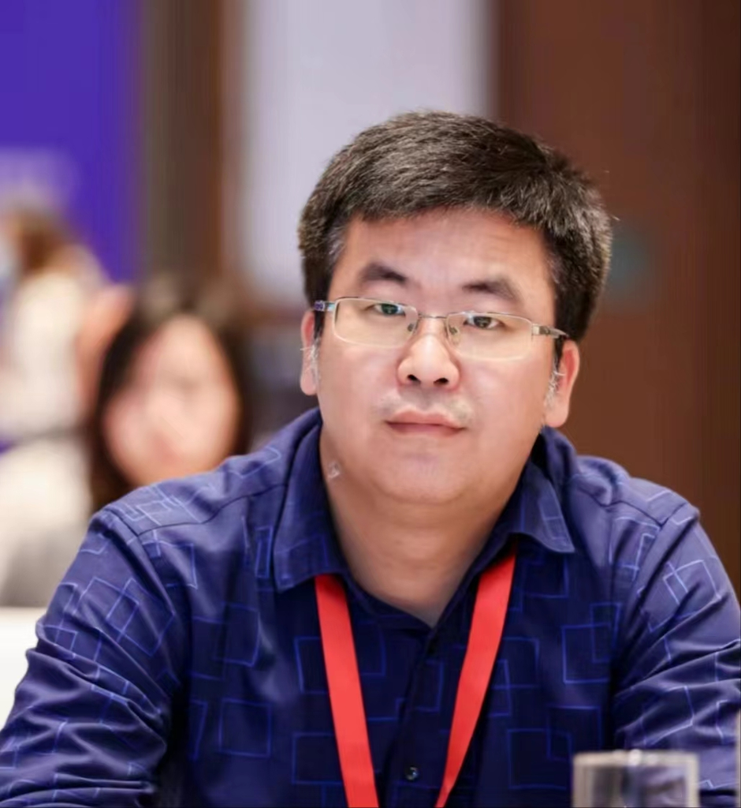

## Contact

- gcyu1@smu.edu.cn
- guangchuangyu
- github.com/YuLab-SMU
- https://yulab-smu.top/
- YuLabSMU (公众号)
- +86-20-61648632
- Highly Cited Researcher
- Citation = 71198
- H-index = 41
- I10-index = 62

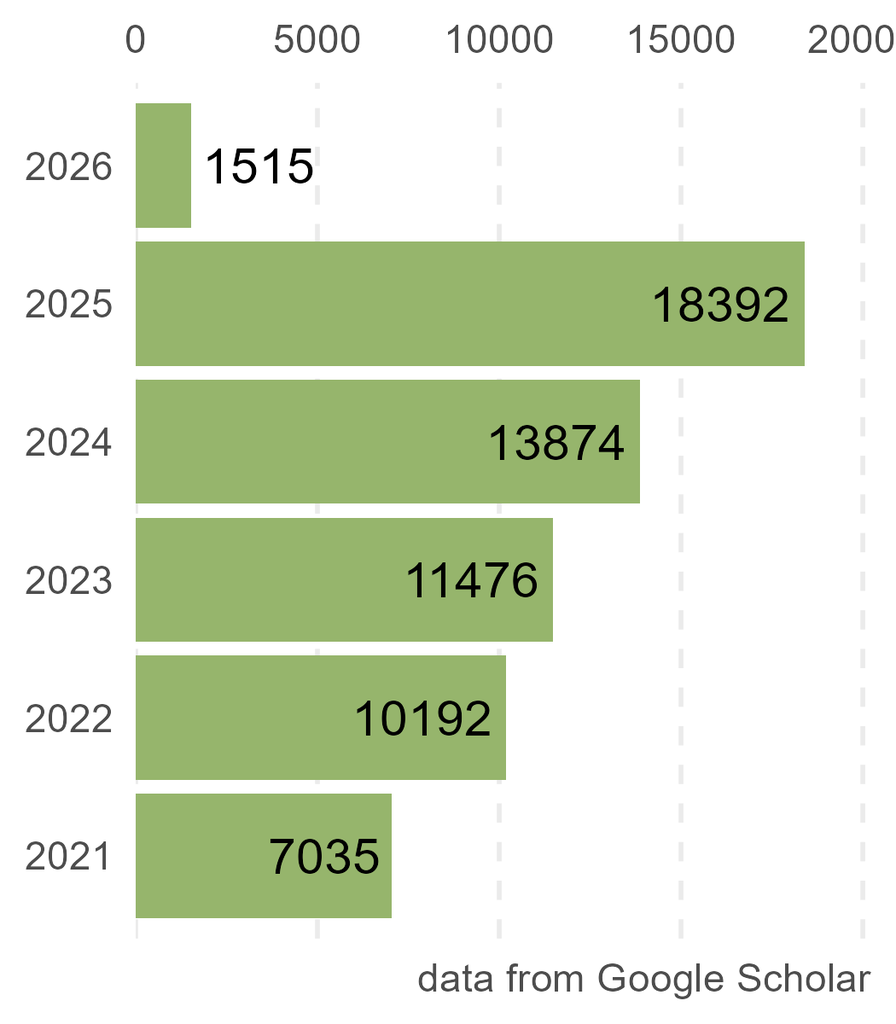

## Disclaimer

Last updated on 2026-02-01.

# Main

## Guangchuang Yu

Professor and dean of the Department of Bioinformatics, School of Basic Medicine, Southern Medical University.

My research group is dedicated to developing innovative methods, tools, and novel analytical approaches through multidisciplinary integration to address complex problems in the field of biomedicine.

教授、博导，现任南方医科大学基础医学院生物信息学系系主任。

课题组致力于通过多学科交叉融合，开发创新方法、工具以及新颖的分析手段，以解决生物医学领域复杂问题。

## Research Experience

### Professor

School of Basic Medical Sciences

Southern Medical University

present - 2018

- 2021-present, Director, Department of Bioinformatics
- 2019-2021, Associate director, Department of Bioinformatics

### Post-doctoral Fellow

State Key Laboratory of Infectious Diseases

The University of Hong Kong

2018 - 2017

### Bioinformatician

Key Laboratory of Functional Protein Research of Guangdong Higher Education Institutes

Jinan University

2013 - 2009

## Education

### PhD., Bioinformaitcs

The University of Hong Kong

Hong Kong, CN

2017 - 2013

- Thesis: Big-data computational methods for studying molecular evolution: from accurate genome assembly to phylogenetic analysis and data integration

### M.S., Biochemistry and Molecular Biology

Anhui Medical University

Hefei, CN

2009 - 2006

- Thesis: miRNA靶基因计算分析新方法及其应用研究

### B.S., Biotechnology

South China Agricultural University

Guangzhou, CN

2005 - 2001

### Antigenic cartography and antibody landscapes course

University of Cambridge

Cambridge, UK

2019

### 南方医科大学高层次人才“不忘初心 牢记使命”学习教育

延安干部培训学院

Yan’an, CN

2018

### Train the Trainers

Institut Pasteur

Paris, FR

2015

### Visiting student

Beijing Institute of Radiation Medicine

Beijing, CN

2009 - 2007

## Certificate

### 高等学校教师资格

广东省教育厅

N/A

2019

### Certificate of Teaching and Learning in Higher Education

Centre for Enhancement of Teaching and Learning

The University of Hong Kong

2015

[figure not shown]

[figure not shown]

[figure not shown]

[figure not shown]

## Scholarships & Awards

### 新锐科学家奖

Wiley

N/A

2025

### Highly Cited Researcher

Clarivate

N/A

2025 - 2023

- 连续3年入选

### “终身科学影响力”排行榜

全球前2%顶尖科学家榜单

N/A

2025 - 2021

- 连续5年入选

### “年度科学影响力”排行榜

全球前2%顶尖科学家榜单

N/A

2025 - 2020

- 连续6年入选

### 中国高被引学者

Elsevier

N/A

2025 - 2021

- 连续5年入选

### Outstanding Contributor

The Innovation

N/A

2025

### Best Paper

The Innovation

N/A

2025 - 2024

### 南医优秀教师

南方医科大学

N/A

2024

### Best Reviewer

The Innovation

N/A

### 2020学年教学优秀一等奖

南方医科大学

N/A

2022

### Postgraduate studentships

The University of Hong Kong

N/A

2017 - 2013

### Best paper of the year 2010

Journal of Integrated OMICS

N/A

2012

## Grants

### 研究生示范课程 “生物信息学”

**主持**, CNY ￥50,000, 广东省研究生教育创新计划项目

N/A

2026 - 2024

### 基于噬菌体-细菌-人类宿主互作的多囊卵巢综合征患者肠道微生态解析与干预 (32270677))

**主持**, CNY ￥540,000, 国家自然科学基金, 面上项目

N/A

2026 - 2023

### 应用型生物信息学专项人才培养计划（特色班）

**主持**, CNY ￥300,000, 广东省高校教学质量与教学改革工程建设项目

N/A

2025 - 2022

### 大样本多组学数据联合分析系统研究与构建

**主持**, CNY ￥600,000, 军科委国防科技创新特区

N/A

2022 - 2020

### 南方医科大学第三层次人才引进科研项目

**主持**, CNY ￥1,500,000

N/A

2020 - 2018

### 病毒性新发传染病的研究与防治 (2017YFE0190800)

**参与**, CNY ￥990,000, 中华人民共和国科学技术部，国家重点研发计划

N/A

### hnRNPK蛋白在调控人肺癌细胞周期胞质分裂中的作用研究 (21613414)

**主持**, CNY ￥100,000, 中央高校基本科研业务费专项资金

N/A

2013

### Hela细胞周期动态蛋白质组学分析 (21611303)

**主持**, CNY ￥20,000, 中央高校基本科研业务费专项资金

N/A

2011

## Books

[figure not shown]

[figure not shown]

### [基于理工信的医学数据采集与分析](https://www.pumpedu.com/en-shop/7263.html)

ISBN: 9787565931987

N/A

2024

- 编委
- 主编：沈百荣，杨恩策
- 北京大学医学出版社

### [R实战：系统发育树的数据集成操作及可视化](https://u.jd.com/uu7G4qC)

ISBN：9787121451829

N/A

2023

- **余光创**（著）, 李林, 罗晓（译）
- 电子工业出版社

### [Data Integration, Manipulation and Visualization of Phylogenetic Trees](https://www.routledge.com/Data-Integration-Manipulation-and-Visualization-of-Phylogenetic-Trees/Yu/p/book/9781032233574)

ISBN: 9781032233574, DOI: 10.1201/9781003279242

N/A

2022

- **G Yu**
- Chapman and Hall/CRC

### [Biomedical Data Visualization: Methods and Applications](https://www.frontiersin.org/research-topics/17918/)

ISBN: 9782889761906, DOI: 10.3389/978-2-88976-190-6

N/A

- **G Yu**, TTY Lam, CL Xiao, M Zhou (eds.)
- Lausanne: Frontiers Media SA

### [Gene Ontology Semantic Similarity Analysis Using GOSemSim](https://doi.org/10.1007/978-1-0716-0301-7_11)

ISBN: 9781071603000, DOI: 10.1007/978-1-0716-0301-7_11

N/A

2020

- **G Yu**
- In: Kidder B. (eds) **Stem Cell Transcriptional Networks**, *Methods in Molecular Biology*, 2117:207-215.
- Humana, New York, NY

## Teaching Experience

### 生物信息学

School of Basic Medical Sciences

Southern Medical University

present - 2024

- PhD level class, invited lecture

### 功能基因组学

School of Basic Medical Sciences

Southern Medical University

- Graduate level class

### 生物技术前沿进展

School of Laboratory Medicine and Biotechnology

Southern Medical University

present - 2023

- Undergraduate level class

### 生物信息学

School of Basic Medical Sciences

Southern Medical University

present - 2022

- Graduate level class

### 毒理学原理与方法

School of Public Health

Southern Medical University

- Graduate level class

### 生物信息学导论

School of Basic Medical Sciences

Southern Medical University

- Undergraduate level class

### 医学研究与医学发展

School of Basic Medical Sciences

Southern Medical University

present - 2021

- Undergraduate level class

### 基因组学

School of Basic Medical Sciences

Southern Medical University

present - 2019

- Undergraduate level class

### 基础医学新进展讲座

School of Basic Medical Sciences

Southern Medical University

- Undergraduate level class

### 生物信息学科研训练

School of Basic Medical Sciences

Southern Medical University

2021 - 2019

- Undergraduate level class

### BMB209: Workshops in Applied Bioinformatics

Department of Biochemistry and Molecular Biology

University of Southern Denmark

2019

- PhD level class, invited lecture

### 功能蛋白质研究

College of Life Science and Technology

Jinan University

2012 - 2011

- Graduate level class

## Publications

### [Gut microbial-derived 3,4-dihydroxyphenylacetic acid ameliorates reproductive phenotype of polycystic ovary syndrome](https://onlinelibrary.wiley.com/doi/10.1002/imt2.70065)

*iMeta*. 2025, 4(5): e70065.

N/A

2025

- P Li<sup>#</sup>, L Xie<sup>#</sup>, H Zheng<sup>#</sup>, Y Feng<sup>#</sup>, F Mai, W Tang, J Wang, Z Lan, S Lv, T Jayawardana, S Koentgen, S Xu, Z Wan, Y Chen, H Xu, S Shen, F Zhang, Y Yang, G Hold, F He*, E M. El-Omar*, **G Yu***, X Chen*

### [Spatial multi-omics profiling of breast cancer oligo-recurrent lung metastasis](https://doi.org/10.1038/s41388-025-03388-y)

*Oncogene*. 2025, 44(27):2268-2282.

N/A

- Y Gao<sup>#</sup>, B Li<sup>#</sup>, Y Jin<sup>#</sup>, J Cheng<sup>#</sup>, W Tian, L Ying, L Hong, S Xin, B Lin, C Liu, X Sun, J Zhang, H Zhang, J Xie, X Deng, X Dai, L Liu, Y Zheng, P Zhao, **G Yu***, W Fang*, X Bao*

### [aplot: Simplifying the creation of complex graphs to visualize associations across diverse data types](https://doi.org/10.1016/j.xinn.2025.100958)

*The Innovation*. 2025, 6(9):100958.

N/A

- S Xu<sup>#</sup>, Q Wang<sup>#</sup>, S Wen<sup>#</sup>, J Li<sup>#</sup>, N He<sup>#</sup>, M Li, T Hackl, R Wang, D Zeng, S Wang, S Li, CH Gao, L Zhou, S Tao, Z Xie, L Deng, **G Yu***

### [Spatial Transcriptomics: Biotechnologies, Computational Tools, and Neuroscience Applications](https://doi.org/10.1002/smtd.202401107)

*Small Methods*. 2025, 9(5):2401107.

N/A

- Q Wang, H Zhu, L Deng, S Xu, W Xie, M Li, R Wang, L Tie, L Zhan, **G Yu***

[figure not shown]

作为期刊当期 frontispiece。

### [16S rRNA Sequencing Reveals Dysbiosis of Skin Microbiome Associated With Disease Severity in Chronic Actinic Dermatitis](https://onlinelibrary.wiley.com/doi/full/10.1111/phpp.70022)

*Photodermatology, Photoimmunology & Photomedicine*. 2025, 41(3):e70022.

N/A

- Y Tu<sup>#*</sup>, S Xu<sup>#</sup>, H Shu, X Wang, W Li, **G Yu***, Li He*

### [Scalable method for exploring phylogenetic placement uncertainty with custom visualizations using treeio and ggtree](https://doi.org/10.1002/imt2.269)

*iMeta*. 2025, 4(1):e269.

N/A

- M Chen<sup>#</sup>, X Luo<sup>#</sup>, S Xu<sup>#</sup>, L Li, J Li, Z Xie, Q Wang, Y Liao, B Liu, W Liang, K Mo, Q Song, X Chen*, TTY Lam*, **G Yu***

### [Enhancing Immuno-Oncology Investigations Through Multidimensional Decoding of Tumour Microenvironment with IOBR 2.0](https://doi.org/10.1016/j.crmeth.2024.100910)

*Cell Reports Methods*. 2024, 4(12):100910.

N/A

2024

- D Zeng<sup>#</sup>, Y Fang<sup>#</sup>, W Qiu; P Luo, S Wang; R Shen, W Gu, X Huang, Q Mao; G Wang, Y Lai; X Xu, M Shi, Z Wu*, **G Yu***, W Liao*

### [Artificial intelligence for life sciences: A comprehensive guide and future trends](https://doi.org/10.59717/j.xinn-life.2024.100105)

*The Innovation Life*. 2024, 2(4):100105.

N/A

- M Luo<sup>*#</sup>, W Yang<sup>#</sup>, L Bai<sup>#</sup>, L Zhang<sup>#</sup>, JW Huang<sup>#</sup>, Y Cao<sup>#</sup>, Y Xie<sup>#</sup>, L Tong, H Zhang, L Yu, LW Zhou, Y Shi, P Yu, Z Wang, Z Yuan, P Zhang, Y Zhang, F Ju, H Zhang, F Wang, Y Cui, J Zhang, G Jia, D Wan, C Ruan, Y Zeng, P Wu, Z Gao, W Zhao, Y Xu, **G Yu**, C Tian, LN Jin, J Dai*, B Xia*, B Sun*, F Chen*, YZ Gao*, H Wang*, B Wang*, D Zhang*, X Cao*, H Wang*, T Huang*

The Innovation Life Best Popular Award。

### [Spatial Resolved Transcriptomics: Computational Insights into Gene Transcription Across Tissue and Organ Architecture in Diverse Applications](https://www.the-innovation.org/article/doi/10.59717/j.xinn-life.2024.100097)

*The Innovation Life*. 2024, 2(4):100097.

N/A

- Z Miao<sup>#</sup>, T Tian<sup>#</sup>, W Chen<sup>#</sup>, Q Wang<sup>#</sup>, L Ma<sup>#</sup>, D Zhang<sup>#</sup>, M Xie<sup>#</sup>, Z Yu<sup>#</sup>, X Guo, G Bai, S Zhao, X Chen, W Wang, Y Gao, S Guo*, M Luo*, L Yuan*, C Tian*, L Wu*, **G Yu***, D Zhang*, S Sun*

### [Thirteen years of clusterProfiler](https://doi.org/10.1016/j.xinn.2024.100722)

*The Innovation*. 2024, 5(6):100722.

N/A

- **G Yu***

The Innovation Best Paper Award。

### [Using clusterProfiler to characterise Multi-Omics Data](https://www.nature.com/articles/s41596-024-01020-z)

*Nature Protocols*. 2024, 19(11):3292-3320.

N/A

- S Xu<sup>#</sup>, E Hu<sup>#</sup>, Y Cai<sup>#</sup>, Z Xie<sup>#</sup>, X Luo<sup>#</sup>, L Zhan, W Tang, Q Wang, B Liu, R Wang, W Xie, T Wu, L Xie, **G Yu***

### [tigeR: Tumor Immunotherapy Gene Expression Data Analysis R package](http://doi.org/10.1002/imt2.229)

*iMeta*. 2024, 3(5):e229.

N/A

- Y Chen<sup>#</sup>, LN He<sup>#</sup>, Y Zhang, J Gong, S Xu, Y Shu, D Zhang*, **G Yu***, Z Zuo*

### [Reducing language barriers, promoting information absorption, and communication using *fanyi*](https://journals.lww.com/cmj/fulltext/2024/08200/reducing_language_barriers,_promoting_information.7.aspx)

*Chinese Medical Journal*. 2024, 137(16):1950-1956.

N/A

- D Wang, G Chen, L Li, S Wen, Z Xie, X Luo, L Zhan, S Xu, J Li, R Wang, Q Wang*, **G Yu***

### [Bioinformatics Software Development: principles and future directions](https://www.the-innovation.org/article/doi/10.59717/j.xinn-life.2024.100083)

*The Innovation Life*. 2024, 2(3):100083.

N/A

- XK Ma<sup>#</sup>, Y Yu<sup>#</sup>, T Huang<sup>#</sup>, D Zhang, C Tian, W Tang, M Luo, P Du*, **G Yu***, L Yang*

### [Computational modeling for medical data: from data collection to knowledge discovery](https://doi.org/10.59717/j.xinn-life.2024.100079)

*The Innovation Life*. 2024, 2(3):100079.

N/A

- Y Yang<sup>#</sup>, S Xu<sup>#</sup>, Y Hong, Y Cai, W Tang, J Wang, B Shen*, H Zong*, **G Yu***

### [shinyTempSignal: an R shiny application for exploring temporal and other phylogenetic signals](https://www.sciencedirect.com/science/article/pii/S167385272400033X)

*Journal of Genetics and Genomics*. 2024, 51(7):762-768.

N/A

- L Zhan<sup>#</sup>, X Luo<sup>#</sup>, W Xie<sup>#</sup>, XA Zhu<sup>#</sup>, Z Xie, J Lin, L Li, W Tang, R Wang, L Deng, Y Liao, B Liu, Y Cai, Q Wang, S Xu*, **G Yu***

### [Resolving Tumor Evolution: A Phylogenetic Approach](https://www.sciencedirect.com/science/article/pii/S2667005424000206)

*Journal of the National Cancer Center*. 2024, 4(2):97-106.

N/A

- L Li, W Xie, L Zhan, S Wen, X Luo, S Xu, Y Cai, W Tang, Q Wang, M Li, Z Xie, L Deng, H Zhu, **G Yu***

### [Decoding the Brain: Unveiling Comprehensive Cellular Atlases through Multiomics Mega Data](https://doi.org/10.1016/j.xinn.2024.100637)

*The Innovation*. 2024, 5(4):100637.

N/A

- Q Wang, W Tang, L Chen, L Deng, **G Yu***

### [Encoding biological metaverse: Advancements and challenges in neural fields from macroscopic to microscopic](https://doi.org/10.1016/j.xinn.2024.100627)

*The Innovation*. 2024, 5(3):100627.

N/A

- Y Cai<sup>#</sup>, W Hu<sup>#</sup>, Y Pei, Hao Zhao*, **G Yu***

### [Gut microbiome and metabolome to discover pathogenic bacteria and probiotics in ankylosing spondylitis](https://www.frontiersin.org/journals/immunology/articles/10.3389/fimmu.2024.1369116)

*Frontiers in Immunology*. 2024, 15:1369116.

N/A

- Y Lai<sup>#</sup>, W Tang<sup>#</sup>, X Luo, H Zheng, Y Zhang*, M Wang*, **G Yu***, Min Yang*

### [ggVennDiagram: intuitive Venn diagram software extended](https://onlinelibrary.wiley.com/doi/10.1002/imt2.177)

*iMeta*. 2024, 3(1):e177.

N/A

- CH Gao, C Chen, T Akyol, A Dusa, **G Yu**, B Cao, P Cai*

### [Robust expansion of phylogeny for fast-growing genome sequence data](https://doi.org/10.1371/journal.pcbi.1011871)

*PLoS Computational Biology*. 2024, 20(2):e1011871.

N/A

- Y Ye<sup>#</sup>, MH Shum<sup>#</sup>, JL Tsui<sup>#</sup>, **G Yu**<sup>#</sup>, DK Smith, H Zhu, JT Wu, Y Guan, TTY Lam*

### [Single-cell and spatial-omics in delineating immune-related diseases](https://www.frontiersin.org/articles/10.3389/fcell.2024.1365242/full)

*Frontiers in Cell and Developmental Biology*. 2024, 12:1365242.

N/A

- S Wen, S Mo, J Zhou, Y Lv, K Khazaie*, **G Yu***

### [The impact of pre-existing influenza antibodies and inflammatory status on the influenza vaccine responses in older adults](https://onlinelibrary.wiley.com/doi/abs/10.1111/irv.13172)

*Influenza and Other Respiratory Viruses*. 2023, 17(7):e13172.

N/A

2023

- M Kang, F Lin, Z Jiang, X Tan, X Lin, Z Liang, C Xiao, Y Xia, W Guan, Z Yang, **G Yu**, M Zanin, S Tang*, SS Wong*

### [MMINP: A computational framework of microbe-Metabolite interactions-based metabolic profiles predictor based on the O2-PLS algorithm](https://dx.doi.org/10.1080/19490976.2023.2223349)

*Gut Microbes*. 2023, 15(1):2223349.

N/A

- W Tang, H Zheng, S Xu, P Li, L Zhan, X Luo, Z Dai, Q Wang, **G Yu***

### [MicrobiotaProcess: A comprehensive R package for deep mining microbiome](https://doi.org/10.1016/j.xinn.2023.100388)

*The Innovation*. 2023, 4(2):100388.

N/A

- S Xu, L Zhan, W Tang, Q Wang, Z Dai, L Zhou, T Feng, M Chen, T Wu, E Hu, **G Yu***

### [Editorial: Computational and Systematic Analysis of Multi-omics Data for Drug Discovery and Development](https://www.frontiersin.org/articles/10.3389/fmed.2023.1146896/full)

*Frontiers in Medicine*. 2023, 10:1146896.

N/A

- S Guo*, D Zhang, H Wang, Q An, **G Yu**, J Han, C Jiang, J Huang

### [Ggtree: A serialized data object for visualization of a phylogenetic tree and annotation data](https://onlinelibrary.wiley.com/doi/full/10.1002/imt2.56)

*iMeta*, 2022, 1(4):e56.

N/A

2022

- S Xu, L Li, X Luo, M Chen, W Tang, L Zhan, Z Dai, TT. Lam, Y Guan, **G Yu***

### [Exploring epigenomic datasets by ChIPseeker](https://onlinelibrary.wiley.com/share/author/GYJGUBYCTRMYJFN2JFZZ?target=10.1002/cpz1.585)

*Current Protocols in Bioinformatics*, 2022, 2(10):e585.

N/A

- Q Wang<sup>#</sup>, M Li<sup>#</sup>, T Wu, L Zhan, L Li, M Chen, W Xie, Z Xie, E Hu, S Xu, **G Yu***

### [Characterization of toxin-antitoxin systems from public sequencing data: a case study in *Pseudomonas aeruginosa*](https://www.frontiersin.org/articles/10.3389/fmicb.2022.951774)

*Frontiers in Microbiology*. 2022, 13:951774.

N/A

- Z Dai, T Wu, S Xu, L Zhou, W Tang, E Hu, L Zhan M Chen, **G Yu***

### [Stemness Analysis Uncovers That The Peroxisome Proliferator-Activated Receptor Signaling Pathway Can Mediate Fatty Acid Homeostasis In Sorafenib-Resistant Hepatocellular Carcinoma Cells](https://doi.org/10.3389/fonc.2022.912694)

*Frontiers in Oncology*. 2022, 12:912694.

N/A

- T Feng<sup>#</sup>, T Wu<sup>#</sup>, Y Zhang<sup>#</sup>, L Zhou<sup>#</sup>, S Liu, L Li, M Li, E Hu, Q Wang, X Fu, L Zhan, Z Xie, W Xie, X Huang*, X Shang*, **G Yu***

### [ggmsa: a visual exploration tool for multiple sequence alignment and associated data](https://doi.org/10.1093/bib/bbac222)

*Briefings in Bioinformatics*. 2022, 23(4):bbac222.

N/A

- L Zhou<sup>#</sup>, T Feng<sup>#</sup>, S Xu, F Gao, TT Lam, Q Wang, T Wu, H Huang, L Zhan, L Li, Y Guan, Z Dai*, **G Yu***

### [CBNplot: Bayesian network plots for enrichment analysis](https://doi.org/10.1093/bioinformatics/btac175)

*Bioinformatics*. 2022, 38(10):2959-2960.

N/A

- N Sato, Y Tamada, **G Yu**, Y Okuno*

### [Editorial: Biomedical Data Visualization: Methods and Applications](https://www.frontiersin.org/articles/10.3389/fgene.2022.890775/full)

*Frontiers in Genetics*. 2022, 13:890775.

N/A

- T Wu, CL Xiao, TT Lam, **G Yu***

### [Altered gut microbiota as an auxiliary diagnostic indicator for patients with fracture-related infection](https://www.frontiersin.org/articles/10.3389/fmicb.2022.723791/full)

*Frontiers in Microbiology*. 2022, 13:723791.

N/A

- X Zhao<sup>#</sup>, W Tang<sup>#</sup>, H Wan<sup>#</sup>, Z Lan H Qin, Q Lin, Y Hu, **G Yu***, N Jiang*, B Yu*

### [Use ggbreak to effectively utilize plotting space to deal with large datasets and outliers](https://www.frontiersin.org/articles/10.3389/fgene.2021.774846)

*Frontiers in Genetics*. 2021, 12:774846.

N/A

2021

- S Xu<sup>#</sup>, M Chen<sup>#</sup>, T Feng, L Zhan, L Zhou, **G Yu***

### [clusterProfiler 4.0: A universal enrichment tool for interpreting omics data](https://doi.org/10.1016/j.xinn.2021.100141)

*The Innovation*. 2021, 2(3):100141.

N/A

- T Wu<sup>#</sup>, E Hu<sup>#</sup>, S Xu, M Chen, P Guo, Z Dai, T Feng, L Zhou, W Tang, L Zhan, X Fu, S Liu, X Bo*, **G Yu***

[figure not shown]

Cell Press 官网 Banner Featured；获 Innovation Best Paper/Most Read/Most Download。

### [ggtreeExtra: Compact visualization of richly annotated phylogenetic data](https://doi.org/10.1093/molbev/msab166)

*Molecular Biology and Evolution*. 2021, 38(9):4039-4042.

N/A

- S Xu, Z Dai, P Guo, X Fu, S Liu, L Zhou, W Tang, T Feng, M Chen, L Zhan, T Wu, E Hu, Y Jiang*, X Bo*, **G Yu***

### [ggVennDiagram: An intuitive, easy-to-use, and highly customizable R package to generate Venn diagram](https://doi.org/10.3389/fgene.2021.706907)

*Frontiers in Genetics*. 2021, 12:706907.

N/A

- CH Gao, **G Yu**, P Cai*

### [IOBR: Multi-Omics Immuno-Oncology Biological Research to Decode Tumor Microenvironment and Signatures](https://doi.org/10.3389/fimmu.2021.687975)

*Frontiers in Immunology*. 2021, 12:687975.

N/A

- D Zeng<sup>#</sup>, Z Ye<sup>#</sup>, R Shen, G Yu, J Wu, Y Xiong, R Zhou, W Qiu, N Huang, L Sun, X Li, J Bin, Y Liao, M Shi, W Liao*

### [nCov2019: an R package for studying the COVID-19 coronavirus pandemic](https://doi.org/10.7717/peerj.11421)

*PeerJ*. 2021, 9:e11421.

N/A

- T Wu, E Hu, X Ge*, G Yu***

### [TreeSummarizedExperiment: a S4 class for data with hierarchical structure](https://doi.org/10.12688/f1000research.26669.2)

*F1000Research*. 2021, 9:1246.

N/A

- R Huang, C Soneson, FGM Ernst, KC Rue-Albrecht, **G Yu**, SC Hicks, MD Robinson*

### [Identification of prognostic Stromal-Immune Score-Based Genes in Hepatocellular Carcinoma microenvironment](https://www.frontiersin.org/articles/10.3389/fgene.2021.625236)

*Frontiers in Genetics*. 2021, 12: 625236.

N/A

- S Liu, **G Yu***, L Liu*, X Zou, L Zhou, E Hu, Y Song

### [Gut microbiota and metabolite alterations associated with reduced bone mineral density or bone metabolic indexes in postmenopausal osteoporosis](https://doi.org/10.18632/aging.103168)

**Aging (Albany NY)**. 2020, 12(9):8583-8604.

N/A

2020

- J He<sup>#</sup>, S Xu<sup>#</sup>, B Zhang, C Xiao, Z Chen, F Si, J Fu, X Lin, G Zheng*, **G Yu***, J Chen*

### [Using ggtree to Visualize Data on Tree-Like Structure](https://doi.org/10.1002/cpbi.96)

*Current Protocols in Bioinformatics, 69(1):e96*

N/A

- **G Yu***

### [treeio: an R package for phylogenetic tree input and output with richly annotated and associated data](https://doi.org/10.1093/molbev/msz240)

**Molecular Biology and Evolution**. 2020, 37(2):599-603.

N/A

- LG Wang, TTY Lam, S Xu, Z Dai, L Zhou, T Feng, P Guo, CW Dunn, BR Jones, T Bradley, H Zhu, Y Guan, Y Jiang, **G Yu***
- Impact Factor = 16.24
- ESI Highly Cited Paper

### [RIdeogram: drawing SVG graphics to visualize and map genome-wide data on the idiograms](https://peerj.com/articles/cs-251/)

**PeerJ Computer Science**. 2020, 6:e251.

N/A

- Z Hao, D Lv, Y Ge, J Shi, D Weijers, **G Yu***, J Chen*
- ESI Highly Cited Paper

### [Two methods for mapping and visualizing associated data on phylogeny using ggtree](https://academic.oup.com/mbe/article-abstract/35/12/3041/5142656)

**Molecular Biology and Evolution**. 2018, 35(12):3041-3043.

N/A

2018

- **G Yu***, TTY Lam, H Zhu, Y Guan*
- Impact Factor = 14.797

### [Using meshes for MeSH term enrichment and semantic analyses](https://doi.org/10.1093/bioinformatics/bty410)

*Bioinformatics*. 2018, 34(21):3766–3767.

N/A

- **G Yu***

### [ggtree: an R package for visualization and annotation of phylogenetic trees with their covariates and other associated data](http://onlinelibrary.wiley.com/doi/10.1111/2041-210X.12628/abstract)

*Methods in Ecology and Evolution*. 2017, 8(1):28-36

N/A

2017

- **G Yu**, DK Smith, H Zhu, Y Guan, TTY Lam*
- ESI Highly Cited Paper

[figure not shown]

作为 feature article 入选 *Methods in Ecology and Evolution* 10 周年纪念专辑。

### [ReactomePA: an R/Bioconductor package for reactome pathway analysis and visualization](http://pubs.rsc.org/en/Content/ArticleLanding/2016/MB/C5MB00663E)

*Molecular BioSystems*. 2016, 12(2):477-479

N/A

2016

- **G Yu**, QY He*
- ESI Highly Cited Paper

### [Integrated Translatomics with Proteomics to Identify Novel Iron–Transporting Proteins in *Streptococcus pneumoniae*](http://journal.frontiersin.org/article/10.3389/fmicb.2016.00078/full)

*Frontiers in Microbiology*. 2016, 7:78

N/A

- XY Yang, K He, G Du, X Wu, **G Yu**, Y Pan, G Zhang*, X Sun*, QY He*

### [Genetic characterization of highly pathogenic H5 influenza viruses from poultry in Taiwan, 2015](http://www.sciencedirect.com/science/article/pii/S1567134815300721)

*Infection, Genetics and Evolution*. 2016, 38:96-100

N/A

- PY Huang, CCD Lee, CH Yip, CL Cheung, **G Yu**, TTY Lam, DK Smith, H Zhu*, Y Guan*

### [ChIPseeker: an R/Bioconductor package for ChIP peak annotation, comparision and visualization](https://academic.oup.com/bioinformatics/article/31/14/2382/255379)

*Bioinformatics*. 2015, 31(14):2382-2383

N/A

2015

- **G Yu***, LG Wang, QY He*
- ESI Highly Cited Paper

### [DOSE: an R/Bioconductor package for Disease Ontology Semantic and Enrichment analysis](https://academic.oup.com/bioinformatics/article/31/4/608/2748221)

*Bioinformatics*. 2015, 31(4):608-609

N/A

- **G Yu***, LG Wang, GR Yan, QY He*
- ESI Highly Cited Paper

### [ACK1 Promotes Gastric Cancer Epithelial-Mesenchymal Transition and Metastasis through AKT-POU2F1-ECD Signaling](http://onlinelibrary.wiley.com/doi/10.1002/path.4515/abstract)

*Journal of Pathology*. 2015, 236(2):175-185

N/A

- SH Xu, JZ Huang, ML Xu, **G Yu**, XF Yin, D Chen*, GR Yan*

### [Proteomic analysis on the copper resistance of *Streptococcus pneumonia*](http://pubs.rsc.org/en/content/articlelanding/2015/mt/C4MT00276H)

*Metallomics*. 2015, 7(3):448-454

N/A

- Z Guo, J Han, XY Yang, K Cao, K He, G Du, G Zeng, L Zhang, **G Yu**, Z Sun, QY He*, X Sun*

### [Proteomic analysis on the antibacterial activity of a Ru(II) complex against *Strepococcus pneumonia*](http://www.sciencedirect.com/science/article/pii/S1874391914005521)

*Journal of Proteomics*. 2015, 115:107-116

N/A

- XY Yang, L Zhang, J Liu, N Li, **G Yu**, K Cao, J Han, G Zeng, Y Pan, X Sun*, QY He*

### [Proteomic analysis of putative heme-binding proteins in *Streptococcus pyogenes*](http://pubs.rsc.org/en/content/articlelanding/2014/mt/c4mt00027g)

*Metallomics*. 2014, 6(8):1451-1459

N/A

2014

- N Wang<sup>#</sup>, J Zhang<sup>#</sup>, L Zhang, XY Yang, N Li, **G Yu**, J Han, K Cao, Z Guo, X Sun*, QY He*

### [Putative cobalt- and nickel-binding proteins and motifs in *Streptococcus pneumonia*](http://pubs.rsc.org/en/content/articlelanding/2013/mt/c3mt00126a)

*Metallomics*. 2013, 5(7):928-935

N/A

2013

- X Sun<sup>#</sup>, **G Yu**<sup>#</sup>, Q Xu, N Li, C Xiao, X Yin, K Cao, J Han, QY He*

### [A novel andrographolide derivative AL-1 exerts its cytotoxicity on K562 cells through a ROS-dependent mechanism](http://onlinelibrary.wiley.com/doi/10.1002/pmic.201200273/abstract)

*Proteomics*, 2013, 13(1):169-178

N/A

- YY Zhu<sup>#</sup>, **G Yu**<sup>#</sup>, Y Zhang, Z Xu, YQ Huang, GR Yan*, QY He*

### [A DNA-Based Semantic Fusion Model for Remote Sensing Data](http://www.plosone.org/article/info%3Adoi%2F10.1371%2Fjournal.pone.0077090)

*PLoS One*. 2013, 8(10):e77090

N/A

- H Sun*, J Weng, **G Yu**, RH Massawe

### [Quantitative Proteomics Characterization on the Anti-tumor Effects of Isodexyelephantopin against Nasopharyngeal Carcinoma](http://onlinelibrary.wiley.com/doi/10.1002/pmic.201300152/abstract)

*Proteomics*. 2013, 13(21):3222-3232

N/A

- GR Yan<sup>#</sup>, Z Tan<sup>#</sup>, Y Wang, ML Xu, **G Yu**, Y Li*, QY He*

### [Design, SAR, angiogenic activities evaluation and pro-angiogenic mechanism of new marine cyclopeptide analogs](http://www.eurekaselect.com/107734/article)

*Current Medicinal Chemistry*. 2013, 20(9):1183-1194

N/A

- J Li, X Lu, Q Wu, **G Yu**, Z Xu, L Qiu, Z Pei, Y Lin, J Pang*

### [Proteomic investigation of the interactome of FMNL1 in hematopoietic cells unveils a role in calcium-dependent membrane plasticity](http://www.sciencedirect.com/science/article/pii/S1874391912007567)

*Journal of Proteomics*. 2013, 78:72-82

N/A

- Y Han, **G Yu**, H Sarioglu, A Caballero-Martinez, F Schlott, M Ueffing, H Haase, C Peschel, AM Krackhardt*

### [LXtoo: an integrated live Linux distribution for the bioinformatics community](http://www.biomedcentral.com/1756-0500/5/360/)

*BMC Research Notes*. 2012, 5(1):360

N/A

2012

- **G Yu**<sup>#</sup>, LG Wang<sup>#</sup>, XH Meng, QY He*

### [clusterProfiler: an R package for comparing biological themes among gene clusters](http://online.liebertpub.com/doi/abs/10.1089/omi.2011.0118)

*OMICS: A Journal of Integrative Biology*. 2012, 16(5):284-287

N/A

- **G Yu**, LG Wang, Y Han, QY He*
- ESI Highly Cited Paper

[figure not shown]

入选《2021年中国科技论文统计报告》高被引论文引用次数TOP10（2011-2021）。

### [Cellular MicroRNA let-7c Inhibits M1 Protein Expression of the H1N1 Influenza A Virus in Infected Human Lung Epithelial Cells](http://onlinelibrary.wiley.com/doi/10.1111/j.1582-4934.2012.01572.x/abstract)

*Journal of Cellular and Molecular Medicine*. 2012, 16(10):2539-2546

N/A

- Y Ma<sup>#</sup>, J Yang<sup>#</sup>, X Fan<sup>#</sup>, H Zhao, W Hu, Z Li, **G Yu**, X Ding, J Wang, X Bo, X Zheng, Z Zhou*, S Wang*

### [Genistein-induced mitotic arrest of gastric cancer cells by downregulating KIF20A, a proteomics study](http://onlinelibrary.wiley.com/doi/10.1002/pmic.201100652/abstract)

*Proteomics*. 2012, 12(14):2391-2399

N/A

- GR Yan<sup>#</sup>, FY Zhou<sup>#</sup>, BL Dang, Y Zhang, **G Yu**, X Liu, QY He*

### [Functional similarity analysis of human virus-encoded miRNAs](https://jclinbioinformatics.biomedcentral.com/articles/10.1186/2043-9113-1-15)

*Journal of Clinical Bioinformatics*. 2011, 1(1):15

N/A

2011

- **G Yu**, QY He*

### [A new method for measuring functional similarity of microRNAs](http://www.jiomics.com/index.php/jio/article/view/21)

*Journal of Integrated OMICS*. 2011, 1(1):49-54

N/A

- **G Yu**<sup>#</sup>, CL Xiao<sup>#</sup>, X Bo, CH Lu, Y Qin, S Zhan, QY He*

### [Phosphoproteome profile of human lung cancer cell line A549](http://pubs.rsc.org/en/Content/ArticleLanding/2011/MB/C0MB00055H)

*Molecular BioSystems*. 2011, 7(2):472-479

N/A

- **G Yu**<sup>#</sup>, CL Xiao<sup>#</sup>, CH Lu<sup>#</sup>, HT Jia, F Ge, W Wang, XF Yin, HL Jia, JX He*, QY He*

### [Proteomic Analysis of Membrane Proteins from *Streptococcus pneumoniae* with Multiple Separation Methods plus High Accuracy Mass Spectrometry](http://www.liebertonline.com/doi/abs/10.1089/omi.2010.0133)

*OMICS: A Journal of Integrative Biology*. 2011, 15(10):683-694

N/A

- X Sun<sup>#</sup>, XY Yang<sup>#</sup>, XF Yin, **G Yu**, CL Xiao, X He, QY He*

### [GOSemSim: an R package for measuring semantic similarity among GO terms and gene products](http://bioinformatics.oxfordjournals.org/cgi/content/abstract/26/7/976)

*Bioinformatics*. 2010, 26(7):976-978

N/A

2010

- **G Yu**<sup>#</sup>, F Li<sup>#</sup>, Y Qin, X Bo*, Y Wu, S Wang*

### 结合基因组分析预测炎症相关miRNA及其靶标

*军事医学科学院院刊*. 2009, 33(3):245-247

N/A

2009

- **余光创**，王超，许尹，伯晓晨，王升启*，秦宜德*

### 依赖于5’端非编码区高级结构的真核生物mRNA翻译调控

*中国生物化学与分子生物学报*. 2007, 23(11):881-887

N/A

2007

- **余光创**，秦宜德，伯晓晨，王升启*

## Professional affliations

### 国际计算生物学学会中国理事会

教育与培训工作委员会委员

N/A

present - 2025

### 中国生物物理学会

生物医学信息学分会委员

N/A

### 中国毒理协会

人工智能毒理专业委员会委员

N/A

### 中国抗癌协会

肿瘤基因诊断专业委员会委员

N/A

present - 2024

### The Innovation Academy

Senior Member

N/A

### The Innovation Life

Academic Editor

N/A

present - 2023

### iMeta

Associate Editor

N/A

present - 2022

### The Innovation

Youth Editor

N/A

### 南方医科大学基础医学院第二届学术分委员会

委员

N/A

### 中国生物工程学会

计算生物学与生物信息学专业委员会委员

N/A

present - 2021

### 广东省精准医学应用学会

微生态医学分会常务委员

Guangdong, CN

present - 2020

### 广东省医学会

医学遗传学分会青年委员会副主任委员

Guangdong, CN

### 中国计算机学会

会员

N/A

present - 2019

### 香港大学校友会

会员

N/A

present - 2017

### 广东潮博智库

专家

Guangdong, CN

present - 2014

### 广东省卫生信息网络协会

生成式人工智能分会常务委员

N/A

2030 - 2025

### 广东省生物信息学会

理事

N/A

2028 - 2023

### International Society for Influenza and other Respiratory Virus Disease

Member

N/A

2016

### International Network for Data Analysis

Steering Committee

Institut Pasteur

2015